# model_evaluation

Red Light Green Light Decoding Traffic Signs with Computer Vision

### A deep learning project for traffic sign classification using convolutional neural networks and TensorFlow on the GTSRB dataset.

- Introduction
- Model Architecture
- Training and Evaluation
  - Baseline Model
  - Baseline Model with Class Weights
  - Two Convolutional Layers
  - Baseline Model with Batch Normalization
  - Two Convolutional Layers with Batch Normalization
  - Two Convolutional + Dense Layers
  - Two Convolutional + Dense Layers with Batch Normalization
- Comparative Model Analysis
- Test Set Evaluation
- Interpretation of Test Results

# Introduction

Back to Top

Data Source: [German Traffic Sign Recognition Benchmark (GTSRB) dataset](https://benchmark.ini.rub.de/gtsrb_news.html)

The German Traffic Sign Recognition Benchmark (GTSRB) is a widely used dataset for traffic sign classification, containing over 50,000 labeled images across 43 classes. Each image captures a traffic sign in real-world conditions, with variations in lighting, perspective, and occlusion. Accurate recognition of these signs is critical for autonomous driving, advanced driver-assistance systems, and road safety research.

In this project, the task is to design a series of convolutional neural network (CNN) models capable of classifying traffic signs in the GTSRB dataset. Architectural adjustments—such as class weighting, additional convolutional layers, and batch normalization—are introduced incrementally, allowing us to empirically trace improvements from a simple baseline to a high-performing model.

The following sections detail the model architectures, training and evaluation methods, and results. The focus is on how targeted design choices affect classification performance across both majority and minority classes, ultimately identifying a configuration that maximizes accuracy and generalization.

# Model Architecture

Back to Top

The models are built sequentially, starting from a simple baseline and gradually adding complexity. Key modifications include:

- Class weighting to mitigate imbalance.
- Additional convolutional layers for richer feature extraction.
- Batch normalization to stabilize training and improve calibration.
- Additional dense layers (explored but found to reduce performance).

The seven models implemented are:

- Baseline Model
- Baseline Model + Class Weights
- Baseline Model + Second Conv Layer
- Baseline Model + Batch Normalization
- Baseline Model + Second Conv Layer + Batch Normalization (best performing model)
- Baseline Model + Second Conv Layer + Dense Layer
- Baseline Model + Second Conv Layer + Dense Layer + Batch Normalization

Each component plays a distinct role in shaping performance. Convolutional layers expand the network’s ability to capture increasingly complex visual patterns, while batch normalization reduces internal variance, smoothing out the learning process and improving generalization. Class weighting ensures that minority categories—such as rarely encountered road signs—are not overshadowed by majority classes like common speed limits. Dense layers, in theory, allow for deeper decision boundaries, but in practice they risk overfitting when the signal is already strong.

All models are trained on the GTSRB training set and evaluated on a held-out validation/test split. An input resolution size of 30×30 balances detail with efficiency. Training uses categorical cross-entropy loss with the Adam optimizer, together with early stopping to prevent overfitting. Evaluation relies on accuracy as the primary benchmark, supplemented by class-level precision, recall, and F1-score to give a fuller picture of model performance across all 43 categories.

# Training and Evaluation

Back to Top

The following section presents the training and evaluation results for each model. To help interpret these outputs, here is a guide to what will be shown:

#### Model Summary

- Each evaluation begins with a short recap of the model’s architecture, highlighting which modifications (extra convolutional layers, batch normalization, class weights, etc.) are active. This context helps link back to the design choices described earlier.

#### Training and Loss Curves

- Plots of accuracy and loss over time provide insight into the learning process. Smooth upward trends with converging validation curves indicate stable training, while divergence suggests overfitting.

#### Confusion Matrix

- The confusion matrix displays predicted vs. true labels across all 43 categories. While dense, most cells are zero, making the diagonal the key reference point. A sharp diagonal means strong performance; snaggled or blurred diagonals highlight common sources of error. Of particular note is the upper-left cluster, where speed-limit signs with visually similar designs tend to be confused with one another.

#### Classification Report

- Each model’s precision, recall, F1-score, and support are shown for every class. The report is best read by comparing majority and minority classes—are rare categories still detected reliably, or do they collapse into false negatives? At the bottom, the weighted averages summarize performance across all classes, balancing prevalence with accuracy.

#### Error & Misclassification Analysis

- To make mistakes more tangible, a grid displays examples of the top four most common misclassifications. Each image shows the true label, predicted label, and model confidence. Slight blurriness comes from convolutional feature processing, not the dataset itself. A text summary follows, reporting total misclassifications and the five most frequent error types—often one speed limit confused with another (e.g., 50 km/h mistaken for 80 km/h). A histogram of confidence in misclassifications further clarifies how “sure” the model was when wrong. Flat or low-confidence mistakes suggest uncertainty, while high-confidence errors reveal systematic blind spots.

Together, these elements give a full account of each model’s strengths and weaknesses, preparing the ground for the final comparison of architectures.

## Baseline Model

Back to Top

The baseline architecture follows the classic MNIST CNN structure. It consists of a single convolutional layer with 32 filters (3×3 kernel, ReLU activation) followed by max pooling to reduce spatial dimensions. The extracted features are flattened and passed through a dense layer of 128 units with ReLU activation, regularized by a dropout layer (0.5). The final softmax layer outputs probabilities across all 43 traffic sign categories.

This model was run twice: once with standard categorical cross-entropy loss, and again with class weights applied to address dataset imbalance. The latter ensures that rare classes (e.g., uncommon signs) receive proportionally more influence during training, reducing the risk of the model defaulting to majority categories such as common speed limits.

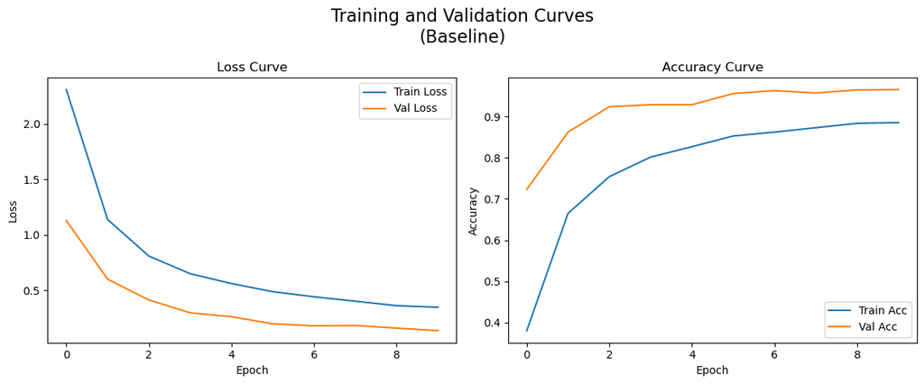

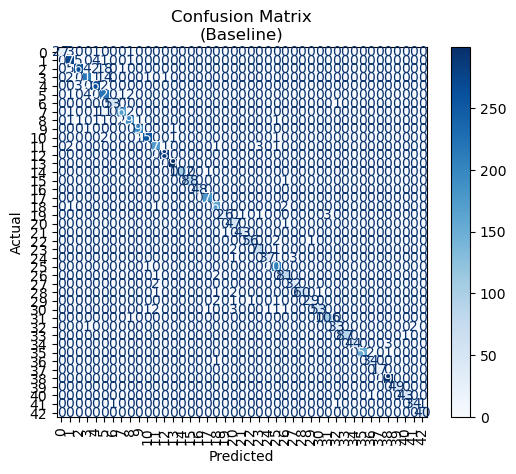

Classification Report

|  | precision | recall | f1-score | support |
| --- | --- | --- | --- | --- |
| accuracy | 0.965653 | 0.965653 | 0.965653 | 0.965653 |
| macro avg | 0.967660 | 0.955663 | 0.960694 | 5328.000000 |
| weighted avg | 0.967178 | 0.965653 | 0.965741 | 5328.000000 |
| 0 | 1.000000 | 0.843750 | 0.915254 | 32.000000 |
| 1 | 0.945017 | 0.961538 | 0.953206 | 286.000000 |
| 2 | 0.967033 | 0.897959 | 0.931217 | 294.000000 |
| 3 | 0.955752 | 0.919149 | 0.937093 | 235.000000 |
| 4 | 0.963370 | 0.981343 | 0.972274 | 268.000000 |
| 5 | 0.817844 | 0.964912 | 0.885312 | 228.000000 |
| 6 | 0.981481 | 0.981481 | 0.981481 | 54.000000 |
| 7 | 0.976744 | 0.918033 | 0.946479 | 183.000000 |
| 8 | 0.965174 | 0.960396 | 0.962779 | 202.000000 |
| 9 | 0.989848 | 0.989848 | 0.989848 | 197.000000 |
| 10 | 0.988372 | 0.980769 | 0.984556 | 260.000000 |
| 11 | 0.960894 | 0.955556 | 0.958217 | 180.000000 |
| 12 | 0.993031 | 1.000000 | 0.996503 | 285.000000 |
| 13 | 0.993355 | 1.000000 | 0.996667 | 299.000000 |
| 14 | 1.000000 | 0.990291 | 0.995122 | 103.000000 |
| 15 | 1.000000 | 0.988764 | 0.994350 | 89.000000 |
| 16 | 1.000000 | 1.000000 | 1.000000 | 48.000000 |
| 17 | 0.988889 | 1.000000 | 0.994413 | 178.000000 |
| 18 | 0.959770 | 0.976608 | 0.968116 | 171.000000 |
| 19 | 0.962963 | 0.838710 | 0.896552 | 31.000000 |
| 20 | 0.839286 | 0.979167 | 0.903846 | 48.000000 |
| 21 | 0.977273 | 0.977273 | 0.977273 | 44.000000 |
| 22 | 0.982456 | 0.949153 | 0.965517 | 59.000000 |
| 23 | 0.946667 | 0.959459 | 0.953020 | 74.000000 |
| 24 | 0.973684 | 0.880952 | 0.925000 | 42.000000 |
| 25 | 0.957944 | 0.995146 | 0.976190 | 206.000000 |
| 26 | 0.941860 | 0.964286 | 0.952941 | 84.000000 |
| 27 | 0.914286 | 0.941176 | 0.927536 | 34.000000 |
| 28 | 1.000000 | 0.923077 | 0.960000 | 65.000000 |
| 29 | 0.966667 | 0.852941 | 0.906250 | 34.000000 |
| 30 | 0.981481 | 0.841270 | 0.905983 | 63.000000 |
| 31 | 0.972477 | 0.990654 | 0.981481 | 107.000000 |
| 32 | 0.942857 | 0.916667 | 0.929577 | 36.000000 |
| 33 | 1.000000 | 0.988636 | 0.994286 | 88.000000 |
| 34 | 1.000000 | 0.936170 | 0.967033 | 47.000000 |
| 35 | 1.000000 | 0.980769 | 0.990291 | 156.000000 |
| 36 | 0.918919 | 0.971429 | 0.944444 | 35.000000 |
| 37 | 1.000000 | 1.000000 | 1.000000 | 17.000000 |
| 38 | 0.986667 | 1.000000 | 0.993289 | 296.000000 |
| 39 | 1.000000 | 1.000000 | 1.000000 | 49.000000 |
| 40 | 0.977273 | 0.977273 | 0.977273 | 44.000000 |
| 41 | 0.944444 | 0.918919 | 0.931507 | 37.000000 |
| 42 | 0.975610 | 1.000000 | 0.987654 | 40.000000 |

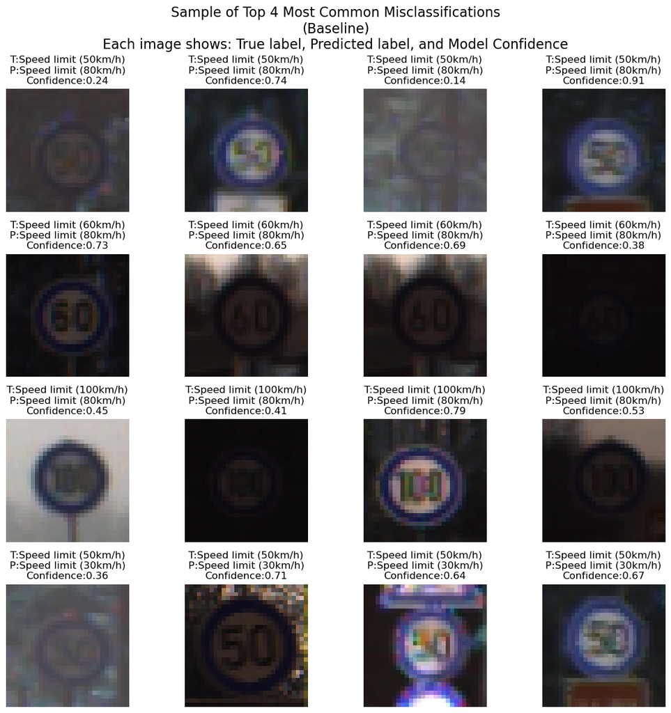

Total Misclassifications: 183

Top 5 Most Common Misclassifications:

* Speed limit (50km/h) (label 2) predicted as Speed limit (80km/h) (label 5) — 18 times

* Speed limit (60km/h) (label 3) predicted as Speed limit (80km/h) (label 5) — 14 times

* Speed limit (100km/h) (label 7) predicted as Speed limit (80km/h) (label 5) — 11 times

* Speed limit (50km/h) (label 2) predicted as Speed limit (30km/h) (label 1) — 5 times

* Speed limit (30km/h) (label 1) predicted as Speed limit (50km/h) (label 2) — 5 times

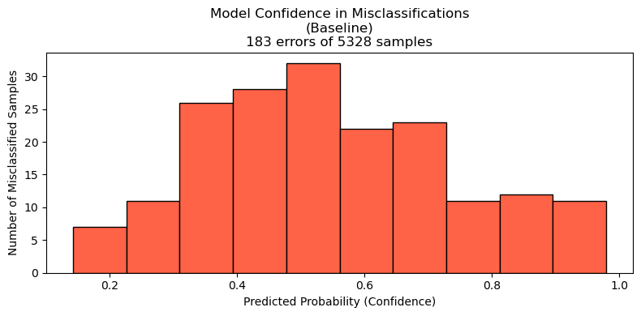

### Results for Baseline Model

The baseline model provides a strong foundation, achieving 96.6% accuracy, with weighted precision, recall, and f1-scores all in the 0.96–0.97 range. While this marks a solid starting point, the results leave clear room for improvement compared to later architectures.

Performance is generally high across most classes, with many achieving precision and recall above 0.95, including several minority categories (e.g., classes 6, 16, 37, 39). However, some weaknesses are apparent. Class 5, representing speed limit signs, is especially problematic: precision falls to 0.82, the lowest among major classes, as the model produces many false positives when confusing visually similar signs (speed limit signs with different numeric values). Other mid-sized classes also show inconsistency, such as class 20 (precision 0.84) and class 30 (recall 0.84). Minority classes are hit-or-miss: some achieve perfect scores, while others (e.g., class 19 with recall 0.84, class 29 with recall 0.85) lag behind.

Training and validation curves show a small gap, likely due to dropout being active during training rather than genuine overfitting. The confidence histogram appears well-calibrated, with predictions spread smoothly across probability bins rather than clustering too sharply at the extremes.

In short, the baseline model demonstrates robust performance but struggles with class imbalance and visually similar categories. These results highlight the need for architectural refinements—such as additional convolutional layers or batch normalization—to boost generalization and reduce systematic errors.

## Baseline Model with Class Weights

Back to Top

The baseline architecture follows the classic MNIST CNN structure. It consists of a single convolutional layer with 32 filters (3×3 kernel, ReLU activation) followed by max pooling to reduce spatial dimensions. The extracted features are flattened and passed through a dense layer of 128 units with ReLU activation, regularized by a dropout layer (0.5). The final softmax layer outputs probabilities across all 43 traffic sign categories.

This is the model's second run, with class weights applied to address dataset imbalance. This ensures that rare classes (e.g., uncommon signs) receive proportionally more influence during training, reducing the risk of the model defaulting to majority categories such as common speed limits. While performance gains on minority classes were noticeable, the model delivered slightly reduced accuracy overall, highlighting design tradeoffs.

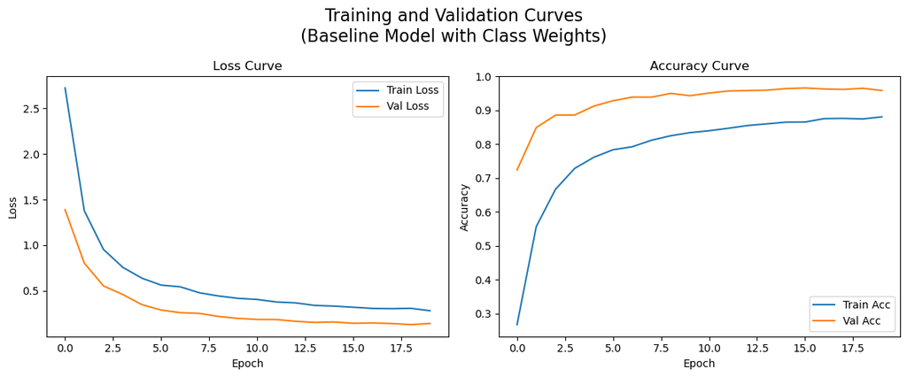

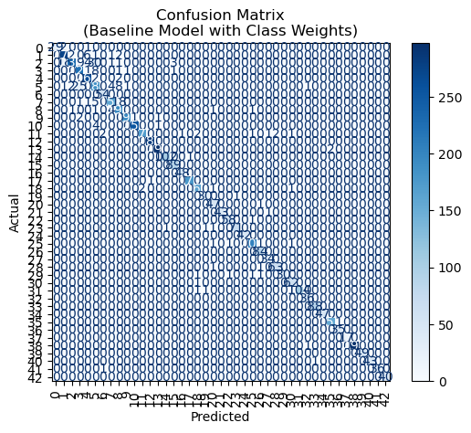

Classification Report

|  | precision | recall | f1-score | support |
| --- | --- | --- | --- | --- |
| accuracy | 0.958333 | 0.958333 | 0.958333 | 0.958333 |
| macro avg | 0.967206 | 0.969188 | 0.967458 | 5328.000000 |
| weighted avg | 0.960015 | 0.958333 | 0.958143 | 5328.000000 |
| 0 | 1.000000 | 0.906250 | 0.950820 | 32.000000 |
| 1 | 0.935154 | 0.958042 | 0.946459 | 286.000000 |
| 2 | 0.978723 | 0.782313 | 0.869565 | 294.000000 |
| 3 | 0.857692 | 0.948936 | 0.901010 | 235.000000 |
| 4 | 0.953069 | 0.985075 | 0.968807 | 268.000000 |
| 5 | 0.784810 | 0.815789 | 0.800000 | 228.000000 |
| 6 | 0.947368 | 1.000000 | 0.972973 | 54.000000 |
| 7 | 0.940476 | 0.863388 | 0.900285 | 183.000000 |
| 8 | 0.858407 | 0.960396 | 0.906542 | 202.000000 |
| 9 | 0.989744 | 0.979695 | 0.984694 | 197.000000 |
| 10 | 0.996094 | 0.980769 | 0.988372 | 260.000000 |
| 11 | 0.988372 | 0.944444 | 0.965909 | 180.000000 |
| 12 | 0.996503 | 1.000000 | 0.998249 | 285.000000 |
| 13 | 0.993311 | 0.993311 | 0.993311 | 299.000000 |
| 14 | 0.990291 | 0.990291 | 0.990291 | 103.000000 |
| 15 | 0.956989 | 1.000000 | 0.978022 | 89.000000 |
| 16 | 0.979592 | 1.000000 | 0.989691 | 48.000000 |
| 17 | 0.994382 | 0.994382 | 0.994382 | 178.000000 |
| 18 | 0.970930 | 0.976608 | 0.973761 | 171.000000 |
| 19 | 0.937500 | 0.967742 | 0.952381 | 31.000000 |
| 20 | 0.903846 | 0.979167 | 0.940000 | 48.000000 |
| 21 | 1.000000 | 0.977273 | 0.988506 | 44.000000 |
| 22 | 0.966667 | 0.983051 | 0.974790 | 59.000000 |
| 23 | 0.986111 | 0.959459 | 0.972603 | 74.000000 |
| 24 | 1.000000 | 1.000000 | 1.000000 | 42.000000 |
| 25 | 0.980583 | 0.980583 | 0.980583 | 206.000000 |
| 26 | 0.954545 | 1.000000 | 0.976744 | 84.000000 |
| 27 | 0.944444 | 1.000000 | 0.971429 | 34.000000 |
| 28 | 0.969231 | 0.969231 | 0.969231 | 65.000000 |
| 29 | 1.000000 | 0.882353 | 0.937500 | 34.000000 |
| 30 | 0.939394 | 0.984127 | 0.961240 | 63.000000 |
| 31 | 1.000000 | 0.971963 | 0.985782 | 107.000000 |
| 32 | 0.947368 | 1.000000 | 0.972973 | 36.000000 |
| 33 | 0.988764 | 1.000000 | 0.994350 | 88.000000 |
| 34 | 1.000000 | 1.000000 | 1.000000 | 47.000000 |
| 35 | 0.987261 | 0.993590 | 0.990415 | 156.000000 |
| 36 | 0.972222 | 1.000000 | 0.985915 | 35.000000 |
| 37 | 1.000000 | 1.000000 | 1.000000 | 17.000000 |
| 38 | 1.000000 | 0.996622 | 0.998308 | 296.000000 |
| 39 | 1.000000 | 1.000000 | 1.000000 | 49.000000 |
| 40 | 1.000000 | 0.977273 | 0.988506 | 44.000000 |
| 41 | 1.000000 | 0.972973 | 0.986301 | 37.000000 |
| 42 | 1.000000 | 1.000000 | 1.000000 | 40.000000 |

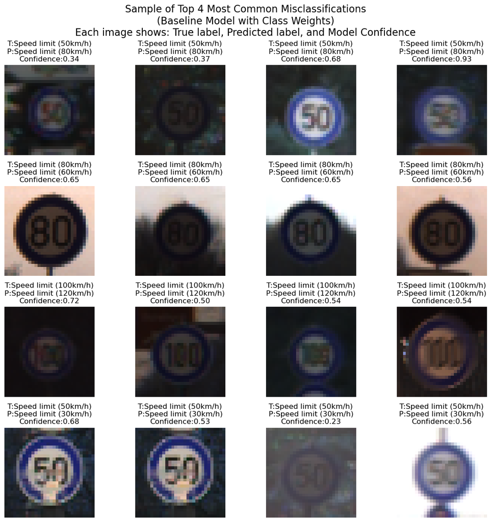

Total Misclassifications: 222

Top 5 Most Common Misclassifications:

* Speed limit (50km/h) (label 2) predicted as Speed limit (80km/h) (label 5) — 30 times

* Speed limit (80km/h) (label 5) predicted as Speed limit (60km/h) (label 3) — 25 times

* Speed limit (100km/h) (label 7) predicted as Speed limit (120km/h) (label 8) — 18 times

* Speed limit (50km/h) (label 2) predicted as Speed limit (30km/h) (label 1) — 16 times

* Speed limit (50km/h) (label 2) predicted as Speed limit (60km/h) (label 3) — 9 times

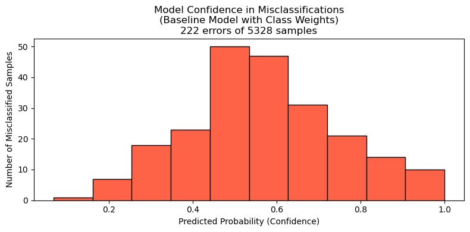

### Results for Baseline Model with Class Weights

The baseline model with class weights reaches 95.8% overall accuracy, with weighted precision, recall, and f1-score all close to 0.96. This is slightly lower than the unweighted baseline, but still demonstrates strong performance.

Applying class weights appears to have shifted trade-offs between precision and recall. In the majority, for example, class 2 shows noticeably lower recall (0.78) despite very high precision (0.98), while classes such as 3 and 8 achieve higher recall (~0.95) at the cost of precision (0.86). Several minority classes (e.g., 24, 27, 32, 34, 36, 42) now achieve perfect or near-perfect scores, suggesting that weighting helped the model attend more to underrepresented categories.

Class 5 continues to be problematic, with both lower precision (0.82 to 0.78) and recall (0.96 to 0.82) compared to the baseline model, indicating that speed limit signs remain a source of confusion even with weighting.

The overall calibration of predictions remains balanced, with no clear evidence of systematic overconfidence or underconfidence.

In short, class weighting improved performance on many minority classes but slightly reduced overall accuracy and consistency, highlighting the trade-off between global performance and minority class support.

## Two Convolutional Layers

Back to Top

Building on the baseline, this architecture introduces a second convolutional layer (64 filters, 3×3 kernel, ReLU) after the first convolution + pooling block. The additional layer allows the network to detect more complex feature hierarchies, such as corners, shapes, or traffic sign symbols, beyond the simple edges and colors captured in the first layer.

After feature extraction, the architecture mirrors the baseline: flattening, a dense layer of 128 units with dropout (0.5), and a final softmax classification layer. This model increases representational capacity while maintaining regularization to guard against overfitting.

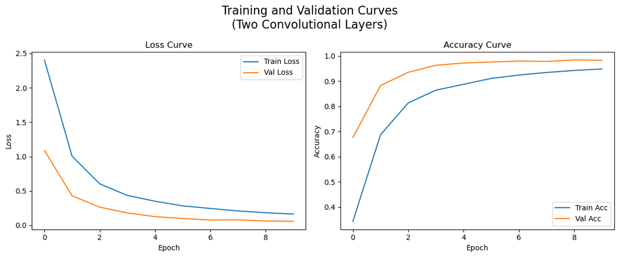

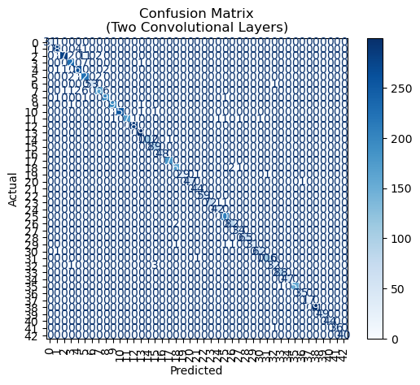

Classification Report

|  | precision | recall | f1-score | support |
| --- | --- | --- | --- | --- |
| accuracy | 0.982733 | 0.982733 | 0.982733 | 0.982733 |
| macro avg | 0.984688 | 0.982062 | 0.983111 | 5328.000000 |
| weighted avg | 0.983218 | 0.982733 | 0.982749 | 5328.000000 |
| 0 | 1.000000 | 0.968750 | 0.984127 | 32.000000 |
| 1 | 0.982517 | 0.982517 | 0.982517 | 286.000000 |
| 2 | 0.992857 | 0.945578 | 0.968641 | 294.000000 |
| 3 | 0.970085 | 0.965957 | 0.968017 | 235.000000 |
| 4 | 0.974170 | 0.985075 | 0.979592 | 268.000000 |
| 5 | 0.895582 | 0.978070 | 0.935010 | 228.000000 |
| 6 | 1.000000 | 0.981481 | 0.990654 | 54.000000 |
| 7 | 0.976608 | 0.912568 | 0.943503 | 183.000000 |
| 8 | 0.961353 | 0.985149 | 0.973105 | 202.000000 |
| 9 | 0.989848 | 0.989848 | 0.989848 | 197.000000 |
| 10 | 1.000000 | 0.988462 | 0.994197 | 260.000000 |
| 11 | 1.000000 | 0.966667 | 0.983051 | 180.000000 |
| 12 | 0.996503 | 1.000000 | 0.998249 | 285.000000 |
| 13 | 0.990066 | 1.000000 | 0.995008 | 299.000000 |
| 14 | 1.000000 | 0.990291 | 0.995122 | 103.000000 |
| 15 | 0.956989 | 1.000000 | 0.978022 | 89.000000 |
| 16 | 1.000000 | 1.000000 | 1.000000 | 48.000000 |
| 17 | 0.994413 | 1.000000 | 0.997199 | 178.000000 |
| 18 | 0.982456 | 0.982456 | 0.982456 | 171.000000 |
| 19 | 1.000000 | 0.935484 | 0.966667 | 31.000000 |
| 20 | 1.000000 | 0.979167 | 0.989474 | 48.000000 |
| 21 | 0.956522 | 1.000000 | 0.977778 | 44.000000 |
| 22 | 1.000000 | 1.000000 | 1.000000 | 59.000000 |
| 23 | 1.000000 | 0.972973 | 0.986301 | 74.000000 |
| 24 | 0.954545 | 1.000000 | 0.976744 | 42.000000 |
| 25 | 0.980952 | 1.000000 | 0.990385 | 206.000000 |
| 26 | 0.964706 | 0.976190 | 0.970414 | 84.000000 |
| 27 | 0.944444 | 1.000000 | 0.971429 | 34.000000 |
| 28 | 1.000000 | 1.000000 | 1.000000 | 65.000000 |
| 29 | 1.000000 | 0.911765 | 0.953846 | 34.000000 |
| 30 | 0.984127 | 0.984127 | 0.984127 | 63.000000 |
| 31 | 0.990654 | 0.990654 | 0.990654 | 107.000000 |
| 32 | 0.941176 | 0.888889 | 0.914286 | 36.000000 |
| 33 | 0.988764 | 1.000000 | 0.994350 | 88.000000 |
| 34 | 1.000000 | 1.000000 | 1.000000 | 47.000000 |
| 35 | 1.000000 | 0.993590 | 0.996785 | 156.000000 |
| 36 | 0.972222 | 1.000000 | 0.985915 | 35.000000 |
| 37 | 1.000000 | 1.000000 | 1.000000 | 17.000000 |
| 38 | 1.000000 | 1.000000 | 1.000000 | 296.000000 |
| 39 | 1.000000 | 1.000000 | 1.000000 | 49.000000 |
| 40 | 1.000000 | 1.000000 | 1.000000 | 44.000000 |
| 41 | 1.000000 | 0.972973 | 0.986301 | 37.000000 |
| 42 | 1.000000 | 1.000000 | 1.000000 | 40.000000 |

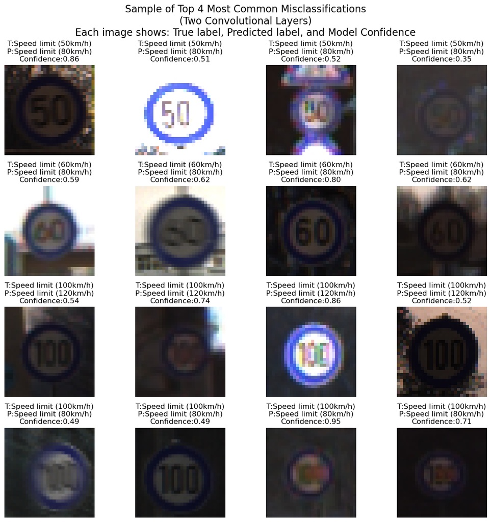

Total Misclassifications: 92

Top 5 Most Common Misclassifications:

* Speed limit (50km/h) (label 2) predicted as Speed limit (80km/h) (label 5) — 11 times

* Speed limit (60km/h) (label 3) predicted as Speed limit (80km/h) (label 5) — 7 times

* Speed limit (100km/h) (label 7) predicted as Speed limit (120km/h) (label 8) — 6 times

* Speed limit (100km/h) (label 7) predicted as Speed limit (80km/h) (label 5) — 6 times

* Speed limit (30km/h) (label 1) predicted as Speed limit (70km/h) (label 4) — 4 times

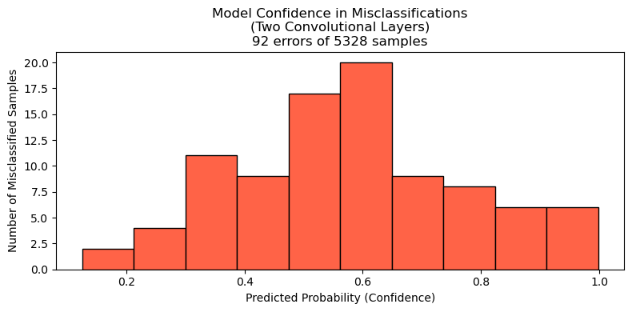

### Results for Two Convolutional Layers

Adding a second convolutional layer significantly improves performance, with overall accuracy rising to 98.3% (vs. 96.6% for the baseline and 95.8% with class weights). Weighted precision, recall, and f1-score all hover around 0.98, marking a clear step up in generalization.

This model shows strong improvements in previously weaker classes. For example, class 5 (a common source of confusion among similar speed limit signs) improves from precision 0.82 (baseline) and 0.78 (Weighted) to 0.90, with recall climbing as high as 0.98. Other historically tricky categories like classes 19, 20, 24, 29, and 30 also report near-perfect metrics, often achieving both precision and recall above 0.95.

In short, the additional convolutional layer boosts feature extraction capacity, leading to higher accuracy, stronger minority class performance, and more consistent predictions across the full label set. This architecture outperforms both the baseline and class weighted models without signs of overfitting.

## Baseline Model with Batch Normalization

Back to Top

This variant augments the baseline with batch normalization after the initial convolutional layer. Batch normalization standardizes intermediate outputs, keeping activations on a consistent scale across batches. This has three benefits: (1) stabilizing training, (2) reducing sensitivity to initialization and learning rates, and (3) improving generalization.

The rest of the architecture mirrors the baseline: one convolutional layer (32 filters), pooling, flattening, a dense layer of 128 units with dropout, and softmax output.

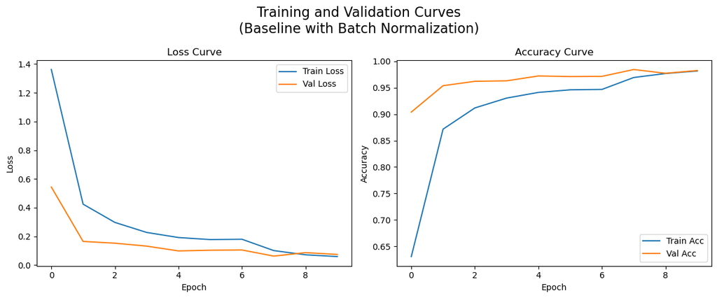

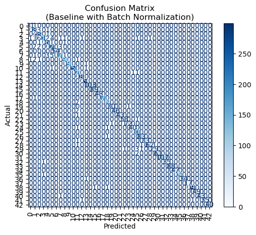

Classification Report

|  | precision | recall | f1-score | support |
| --- | --- | --- | --- | --- |
| accuracy | 0.982545 | 0.982545 | 0.982545 | 0.982545 |
| macro avg | 0.986344 | 0.978723 | 0.982302 | 5328.000000 |
| weighted avg | 0.982805 | 0.982545 | 0.982484 | 5328.000000 |
| 0 | 0.939394 | 0.968750 | 0.953846 | 32.000000 |
| 1 | 0.952703 | 0.986014 | 0.969072 | 286.000000 |
| 2 | 0.956954 | 0.982993 | 0.969799 | 294.000000 |
| 3 | 0.990741 | 0.910638 | 0.949002 | 235.000000 |
| 4 | 0.974265 | 0.988806 | 0.981481 | 268.000000 |
| 5 | 0.952586 | 0.969298 | 0.960870 | 228.000000 |
| 6 | 1.000000 | 1.000000 | 1.000000 | 54.000000 |
| 7 | 0.971910 | 0.945355 | 0.958449 | 183.000000 |
| 8 | 0.985000 | 0.975248 | 0.980100 | 202.000000 |
| 9 | 1.000000 | 0.994924 | 0.997455 | 197.000000 |
| 10 | 1.000000 | 0.992308 | 0.996139 | 260.000000 |
| 11 | 0.951872 | 0.988889 | 0.970027 | 180.000000 |
| 12 | 0.993031 | 1.000000 | 0.996503 | 285.000000 |
| 13 | 0.990066 | 1.000000 | 0.995008 | 299.000000 |
| 14 | 1.000000 | 1.000000 | 1.000000 | 103.000000 |
| 15 | 0.988889 | 1.000000 | 0.994413 | 89.000000 |
| 16 | 1.000000 | 1.000000 | 1.000000 | 48.000000 |
| 17 | 1.000000 | 0.994382 | 0.997183 | 178.000000 |
| 18 | 0.982558 | 0.988304 | 0.985423 | 171.000000 |
| 19 | 0.967742 | 0.967742 | 0.967742 | 31.000000 |
| 20 | 1.000000 | 0.958333 | 0.978723 | 48.000000 |
| 21 | 1.000000 | 0.977273 | 0.988506 | 44.000000 |
| 22 | 0.966667 | 0.983051 | 0.974790 | 59.000000 |
| 23 | 0.986301 | 0.972973 | 0.979592 | 74.000000 |
| 24 | 0.975610 | 0.952381 | 0.963855 | 42.000000 |
| 25 | 0.962617 | 1.000000 | 0.980952 | 206.000000 |
| 26 | 0.976471 | 0.988095 | 0.982249 | 84.000000 |
| 27 | 1.000000 | 0.970588 | 0.985075 | 34.000000 |
| 28 | 0.984127 | 0.953846 | 0.968750 | 65.000000 |
| 29 | 0.966667 | 0.852941 | 0.906250 | 34.000000 |
| 30 | 1.000000 | 0.968254 | 0.983871 | 63.000000 |
| 31 | 1.000000 | 1.000000 | 1.000000 | 107.000000 |
| 32 | 1.000000 | 0.972222 | 0.985915 | 36.000000 |
| 33 | 1.000000 | 1.000000 | 1.000000 | 88.000000 |
| 34 | 1.000000 | 1.000000 | 1.000000 | 47.000000 |
| 35 | 1.000000 | 0.993590 | 0.996785 | 156.000000 |
| 36 | 1.000000 | 0.971429 | 0.985507 | 35.000000 |
| 37 | 1.000000 | 1.000000 | 1.000000 | 17.000000 |
| 38 | 0.996610 | 0.993243 | 0.994924 | 296.000000 |
| 39 | 1.000000 | 1.000000 | 1.000000 | 49.000000 |
| 40 | 1.000000 | 0.977273 | 0.988506 | 44.000000 |
| 41 | 1.000000 | 0.945946 | 0.972222 | 37.000000 |
| 42 | 1.000000 | 1.000000 | 1.000000 | 40.000000 |

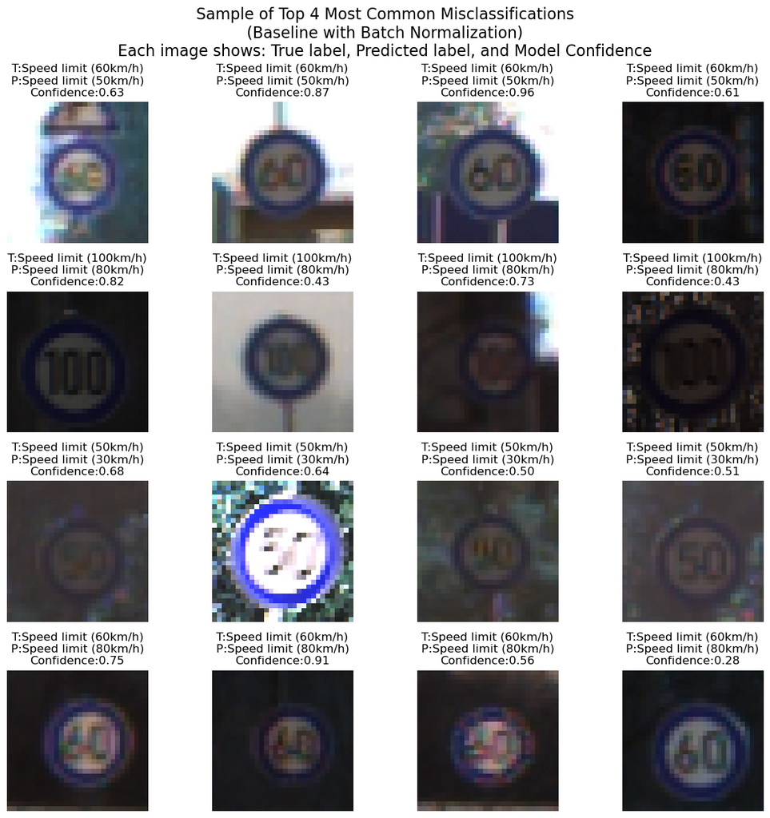

Total Misclassifications: 93

Top 5 Most Common Misclassifications:

* Speed limit (60km/h) (label 3) predicted as Speed limit (50km/h) (label 2) — 6 times

* Speed limit (100km/h) (label 7) predicted as Speed limit (80km/h) (label 5) — 5 times

* Speed limit (50km/h) (label 2) predicted as Speed limit (30km/h) (label 1) — 4 times

* Speed limit (60km/h) (label 3) predicted as Speed limit (80km/h) (label 5) — 4 times

* Speed limit (60km/h) (label 3) predicted as Speed limit (30km/h) (label 1) — 3 times

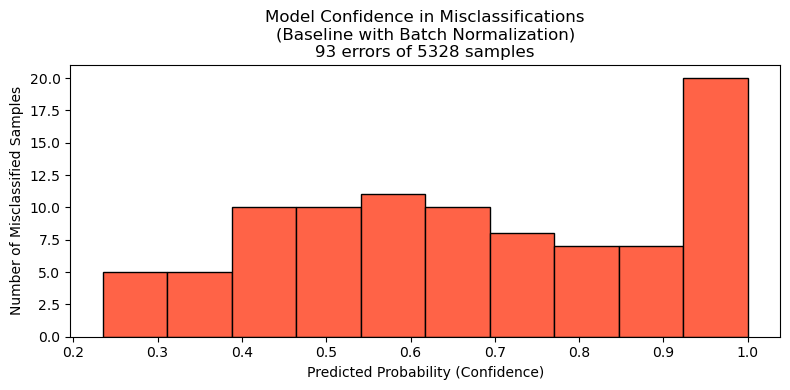

### Results for Baseline Model with Batch Normalization

Introducing batch normalization yields excellent performance, with overall accuracy of 98.3%, nearly identical to the two-convolutional-layer model. Weighted precision, recall, and f1-score are all ~0.983, representing a clear improvement over both the original baseline (96.6%) and the baseline with class weights (95.8%).

Unlike the two-convolutional-layer model, which relied on deeper feature extraction, Batch normalization stabilizes training and leads to faster convergence: the training and validation loss curves align closely, suggesting a well-regularized model with little overfitting.

Performance across classes is broadly consistent, with most precision, recall, and f1-scores above 0.95. Notably, class 5 improves dramatically (precision 0.95, recall 0.97, f1 = 0.96), resolving much of the false-positive issue seen in the baseline (precision 0.82) and Weighted (0.78) models. Minority classes also remain robust, with several (e.g., classes 6, 16, 34, 37, 39, 42) achieving perfect scores. A few smaller classes (e.g., 29 with f1 = 0.91) still lag slightly, though less than before.

One distinction is seen in the confidence histogram: Batch normalization leads to a sharp spike near 0.9–1.0 predicted probabilities, suggesting the model is more confident in its predictions compared to the smoother distribution of the baseline. This does not appear to harm calibration, as misclassifications are fewer and more isolated.

Overall, batch normalization proves as effective as architectural deepening for boosting performance, with the added benefit of improved convergence and stability during training.

## Two Convolutional Layers with Batch Normalization

Back to Top

This model combines the two main improvements explored so far: **a deeper convolutional stack** and **batch normalization**. The architecture features:

- Conv layer (32 filters, 3×3, ReLU) + batch normalization + max pooling
- Conv layer (64 filters, 3×3, ReLU) + batch normalization + max pooling
- Flatten → Dense (128 units, ReLU) + dropout (0.5) → Softmax output

This design improves both **feature richness** and **training stability**, and ultimately delivered the best overall performance among all tested models.

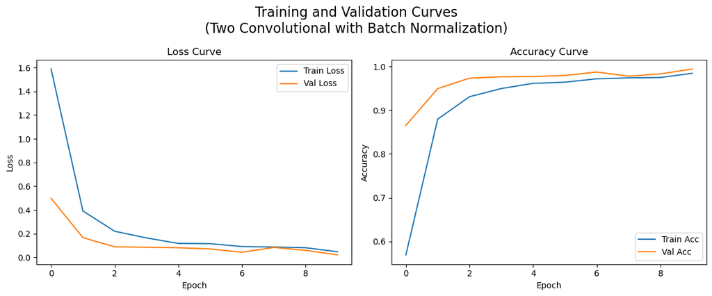

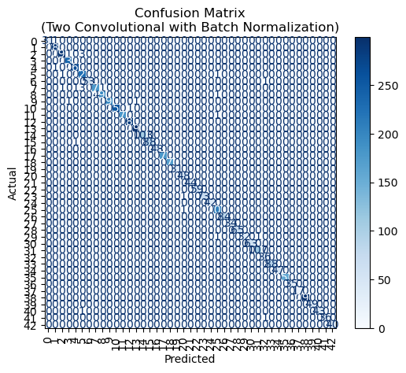

Classification Report

|  | precision | recall | f1-score | support |
| --- | --- | --- | --- | --- |
| accuracy | 0.994182 | 0.994182 | 0.994182 | 0.994182 |
| macro avg | 0.995007 | 0.993229 | 0.994045 | 5328.000000 |
| weighted avg | 0.994251 | 0.994182 | 0.994180 | 5328.000000 |
| 0 | 1.000000 | 0.968750 | 0.984127 | 32.000000 |
| 1 | 0.993056 | 1.000000 | 0.996516 | 286.000000 |
| 2 | 0.993151 | 0.986395 | 0.989761 | 294.000000 |
| 3 | 0.991561 | 1.000000 | 0.995763 | 235.000000 |
| 4 | 0.992565 | 0.996269 | 0.994413 | 268.000000 |
| 5 | 0.969957 | 0.991228 | 0.980477 | 228.000000 |
| 6 | 1.000000 | 0.981481 | 0.990654 | 54.000000 |
| 7 | 0.977901 | 0.967213 | 0.972527 | 183.000000 |
| 8 | 0.994949 | 0.975248 | 0.985000 | 202.000000 |
| 9 | 1.000000 | 0.989848 | 0.994898 | 197.000000 |
| 10 | 1.000000 | 0.996154 | 0.998073 | 260.000000 |
| 11 | 1.000000 | 0.994444 | 0.997214 | 180.000000 |
| 12 | 0.996503 | 1.000000 | 0.998249 | 285.000000 |
| 13 | 0.996667 | 1.000000 | 0.998331 | 299.000000 |
| 14 | 1.000000 | 1.000000 | 1.000000 | 103.000000 |
| 15 | 1.000000 | 0.988764 | 0.994350 | 89.000000 |
| 16 | 1.000000 | 1.000000 | 1.000000 | 48.000000 |
| 17 | 1.000000 | 1.000000 | 1.000000 | 178.000000 |
| 18 | 1.000000 | 1.000000 | 1.000000 | 171.000000 |
| 19 | 1.000000 | 1.000000 | 1.000000 | 31.000000 |
| 20 | 0.960000 | 1.000000 | 0.979592 | 48.000000 |
| 21 | 1.000000 | 1.000000 | 1.000000 | 44.000000 |
| 22 | 1.000000 | 1.000000 | 1.000000 | 59.000000 |
| 23 | 1.000000 | 0.986486 | 0.993197 | 74.000000 |
| 24 | 1.000000 | 1.000000 | 1.000000 | 42.000000 |
| 25 | 0.980861 | 0.995146 | 0.987952 | 206.000000 |
| 26 | 1.000000 | 1.000000 | 1.000000 | 84.000000 |
| 27 | 1.000000 | 1.000000 | 1.000000 | 34.000000 |
| 28 | 1.000000 | 1.000000 | 1.000000 | 65.000000 |
| 29 | 1.000000 | 0.941176 | 0.969697 | 34.000000 |
| 30 | 1.000000 | 1.000000 | 1.000000 | 63.000000 |
| 31 | 0.990741 | 1.000000 | 0.995349 | 107.000000 |
| 32 | 0.947368 | 1.000000 | 0.972973 | 36.000000 |
| 33 | 1.000000 | 1.000000 | 1.000000 | 88.000000 |
| 34 | 1.000000 | 1.000000 | 1.000000 | 47.000000 |
| 35 | 1.000000 | 1.000000 | 1.000000 | 156.000000 |
| 36 | 1.000000 | 1.000000 | 1.000000 | 35.000000 |
| 37 | 1.000000 | 1.000000 | 1.000000 | 17.000000 |
| 38 | 1.000000 | 1.000000 | 1.000000 | 296.000000 |
| 39 | 1.000000 | 1.000000 | 1.000000 | 49.000000 |
| 40 | 1.000000 | 0.977273 | 0.988506 | 44.000000 |
| 41 | 1.000000 | 0.972973 | 0.986301 | 37.000000 |
| 42 | 1.000000 | 1.000000 | 1.000000 | 40.000000 |

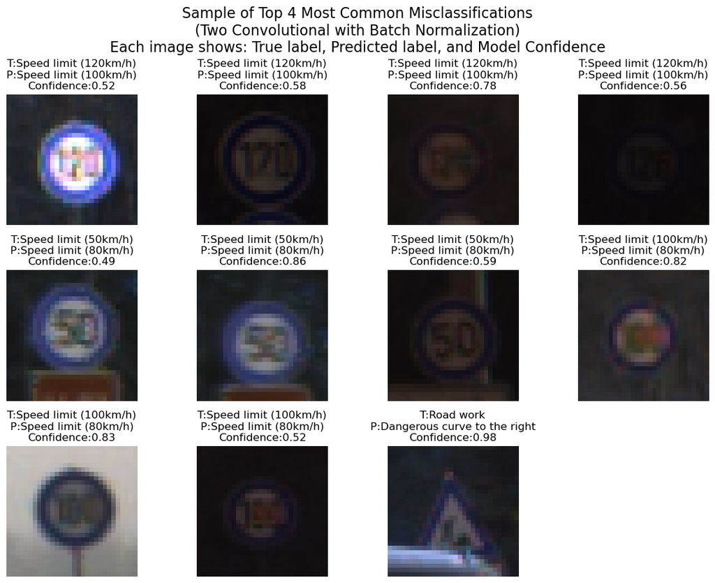

Total Misclassifications: 31

Top 5 Most Common Misclassifications:

* Speed limit (120km/h) (label 8) predicted as Speed limit (100km/h) (label 7) — 4 times

* Speed limit (50km/h) (label 2) predicted as Speed limit (80km/h) (label 5) — 3 times

* Speed limit (100km/h) (label 7) predicted as Speed limit (80km/h) (label 5) — 3 times

* Road work (label 25) predicted as Dangerous curve to the right (label 20) — 1 times

* End of no passing (label 41) predicted as End of all speed and passing limits (label 32) — 1 times

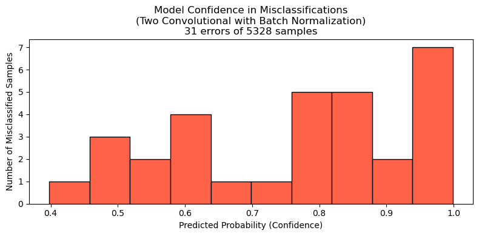

### Results for Two Convolutional Layers with Batch Normalization

Combining batch normalization with a two-layer convolutional block produces the strongest results yet, with overall accuracy reaching 99.4%. Weighted precision, recall, and f1-score are all ~0.994, surpassing both the two-convolutional-layer model (98.3%) and baseline with batch normalization (98.3%) models.

This configuration delivers near-perfect performance across almost all classes. The long-standing challenges with speed limit signs (class 5) are largely resolved, achieving precision 0.97 and recall 0.99. Similarly, smaller or previously inconsistent classes such as 19, 20, 29, and 32 now achieve scores at or near 1.00, with only minor deviations (e.g., class 29 f1 = 0.97).

In short, combining batch normalization with a deeper convolutional block maximizes both accuracy and stability, virtually eliminating misclassifications and setting a new benchmark for performance on this dataset.

## Two Convolutional + Dense Layers

Back to Top

This architecture extends the two-convolutional-layer model by adding an additional dense layer after flattening. Specifically:

- Convolutional stack: 32-filter layer + pooling → 64-filter layer + pooling
- Dense (128 units, ReLU) + dropout (0.5)
- Dense (64 units, ReLU) + dropout (0.5)
- Softmax output

The motivation was to allow the network to learn more complex, non-linear combinations of extracted features. While deeper dense stacks can capture subtler decision boundaries, they also increase risk of overfitting, particularly when feature extraction is already strong.

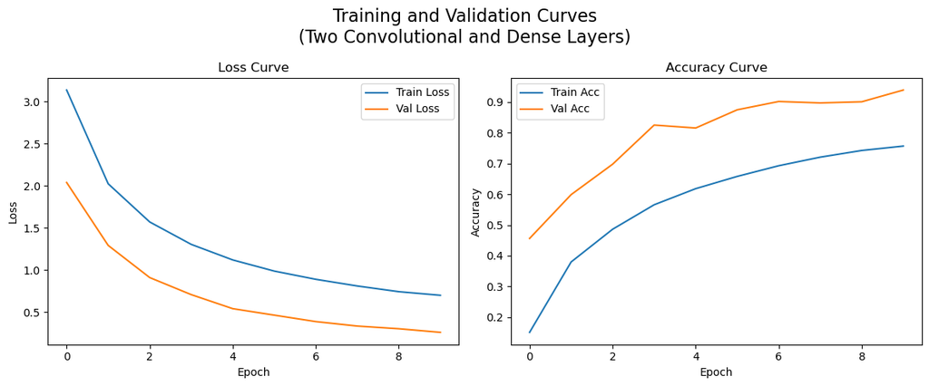

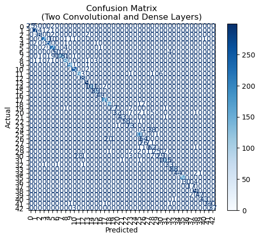

Classification Report

|  | precision | recall | f1-score | support |
| --- | --- | --- | --- | --- |
| accuracy | 0.938251 | 0.938251 | 0.938251 | 0.938251 |
| macro avg | 0.915974 | 0.885795 | 0.890472 | 5328.000000 |
| weighted avg | 0.937184 | 0.938251 | 0.932645 | 5328.000000 |
| 0 | 1.000000 | 0.781250 | 0.877193 | 32.000000 |
| 1 | 0.961938 | 0.972028 | 0.966957 | 286.000000 |
| 2 | 0.979522 | 0.976190 | 0.977853 | 294.000000 |
| 3 | 0.982222 | 0.940426 | 0.960870 | 235.000000 |
| 4 | 0.963504 | 0.985075 | 0.974170 | 268.000000 |
| 5 | 0.898374 | 0.969298 | 0.932489 | 228.000000 |
| 6 | 0.980392 | 0.925926 | 0.952381 | 54.000000 |
| 7 | 1.000000 | 0.655738 | 0.792079 | 183.000000 |
| 8 | 0.764228 | 0.930693 | 0.839286 | 202.000000 |
| 9 | 0.989848 | 0.989848 | 0.989848 | 197.000000 |
| 10 | 0.977273 | 0.992308 | 0.984733 | 260.000000 |
| 11 | 0.857868 | 0.938889 | 0.896552 | 180.000000 |
| 12 | 0.982759 | 1.000000 | 0.991304 | 285.000000 |
| 13 | 0.980328 | 1.000000 | 0.990066 | 299.000000 |
| 14 | 1.000000 | 0.980583 | 0.990196 | 103.000000 |
| 15 | 0.956989 | 1.000000 | 0.978022 | 89.000000 |
| 16 | 0.979592 | 1.000000 | 0.989691 | 48.000000 |
| 17 | 0.983425 | 1.000000 | 0.991643 | 178.000000 |
| 18 | 0.888889 | 0.982456 | 0.933333 | 171.000000 |
| 19 | 1.000000 | 0.870968 | 0.931034 | 31.000000 |
| 20 | 0.969697 | 0.666667 | 0.790123 | 48.000000 |
| 21 | 0.977273 | 0.977273 | 0.977273 | 44.000000 |
| 22 | 1.000000 | 0.983051 | 0.991453 | 59.000000 |
| 23 | 0.829545 | 0.986486 | 0.901235 | 74.000000 |
| 24 | 0.000000 | 0.000000 | 0.000000 | 42.000000 |
| 25 | 0.962441 | 0.995146 | 0.978520 | 206.000000 |
| 26 | 0.653061 | 0.761905 | 0.703297 | 84.000000 |
| 27 | 0.875000 | 0.205882 | 0.333333 | 34.000000 |
| 28 | 0.563636 | 0.953846 | 0.708571 | 65.000000 |
| 29 | 0.961538 | 0.735294 | 0.833333 | 34.000000 |
| 30 | 0.828571 | 0.460317 | 0.591837 | 63.000000 |
| 31 | 0.963303 | 0.981308 | 0.972222 | 107.000000 |
| 32 | 0.868421 | 0.916667 | 0.891892 | 36.000000 |
| 33 | 0.988764 | 1.000000 | 0.994350 | 88.000000 |
| 34 | 1.000000 | 0.936170 | 0.967033 | 47.000000 |
| 35 | 0.993631 | 1.000000 | 0.996805 | 156.000000 |
| 36 | 1.000000 | 0.857143 | 0.923077 | 35.000000 |
| 37 | 0.894737 | 1.000000 | 0.944444 | 17.000000 |
| 38 | 0.973684 | 1.000000 | 0.986667 | 296.000000 |
| 39 | 0.979167 | 0.959184 | 0.969072 | 49.000000 |
| 40 | 0.977273 | 0.977273 | 0.977273 | 44.000000 |
| 41 | 1.000000 | 0.918919 | 0.957746 | 37.000000 |
| 42 | 1.000000 | 0.925000 | 0.961039 | 40.000000 |

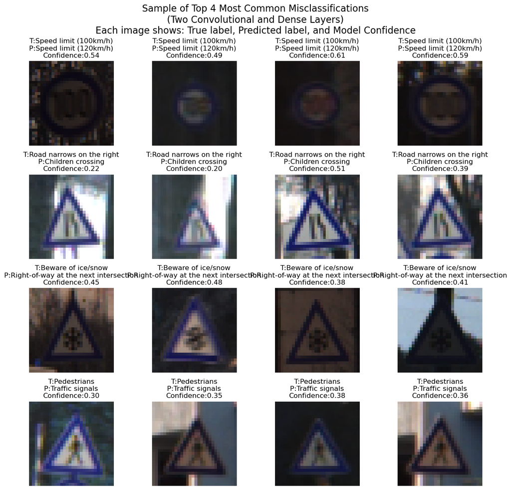

Total Misclassifications: 329

Top 5 Most Common Misclassifications:

* Speed limit (100km/h) (label 7) predicted as Speed limit (120km/h) (label 8) — 51 times

* Road narrows on the right (label 24) predicted as Children crossing (label 28) — 38 times

* Beware of ice/snow (label 30) predicted as Right-of-way at the next intersection (label 11) — 28 times

* Pedestrians (label 27) predicted as Traffic signals (label 26) — 26 times

* Traffic signals (label 26) predicted as General caution (label 18) — 20 times

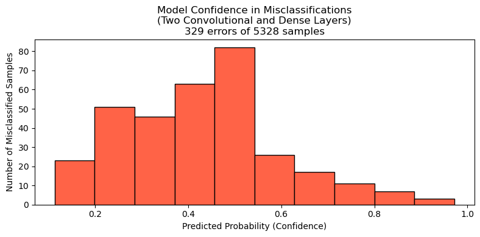

### Results for Two Convolutional + Dense Layers

Adding an extra Dense layer after the two convolutional layers significantly reduces performance compared to earlier models. Overall accuracy drops to 93.8%, with weighted precision, recall, and f1-score all in the 0.93 range—noticeably lower than the ~99% achieved by the best-performing convolutional + batch normalization setups.

The added dense layer appears to destabilize training, leading to inconsistent class-level results. Several classes that previously reached near-perfect precision and recall now show severe degradation. For example, class 24 fails completely (precision/recall/f1 = 0.0), class 27 has recall just 0.21, and classes 20, 28, and 30 all fall below 0.80 f1-scores. Even relatively large classes (e.g., class 7 with f1 = 0.79) suffer, suggesting that the dense layer introduced overfitting or disrupted feature generalization.

While some categories (e.g., classes 12, 13, 17, 35) still achieve perfect or near-perfect performance, the overall pattern is one of instability and uneven generalization. Minority classes that had been well-handled in prior models are disproportionately affected, which explains the large gap between macro-average metrics (precision 0.92, recall 0.89) and weighted averages.

In short, the additional dense layer degrades both global accuracy and minority class performance, indicating that architectural complexity at the dense stage does not benefit this task and instead undermines the strong feature extraction already achieved by the convolutional blocks.

## Two Convolutional + Dense Layers with Batch Normalization

Back to Top

The final variant adds batch normalization to the two-convolution, two-dense model. Normalization layers are applied after each convolutional block, leveling the playing field for subsequent activations.

The architecture is:

- Conv (32 filters, 3×3, ReLU) → BatchNorm → MaxPooling
- Conv (64 filters, 3×3, ReLU) → BatchNorm → MaxPooling
- Flatten → Dense (128 units, ReLU) + Dropout (0.5)
- Dense (64 units, ReLU) + Dropout (0.5)
- Softmax output

This model sought to blend deeper representation power with training stability. While performance gains over the simpler additional Dense variant were noticeable, the design continues to underperform models without the additional complexity.

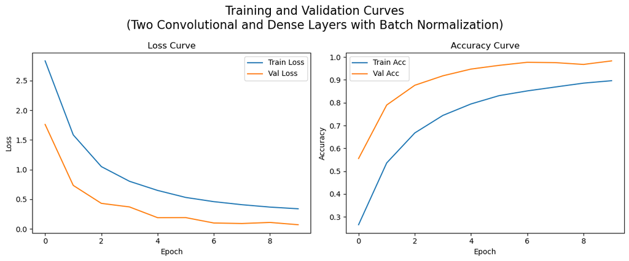

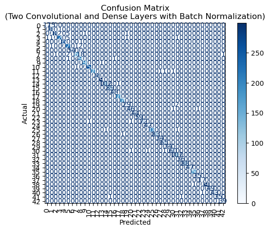

Classification Report

|  | precision | recall | f1-score | support |
| --- | --- | --- | --- | --- |
| accuracy | 0.983108 | 0.983108 | 0.983108 | 0.983108 |
| macro avg | 0.981243 | 0.975459 | 0.976832 | 5328.000000 |
| weighted avg | 0.983436 | 0.983108 | 0.982712 | 5328.000000 |
| 0 | 0.944444 | 0.531250 | 0.680000 | 32.000000 |
| 1 | 0.943709 | 0.996503 | 0.969388 | 286.000000 |
| 2 | 0.996503 | 0.969388 | 0.982759 | 294.000000 |
| 3 | 0.986900 | 0.961702 | 0.974138 | 235.000000 |
| 4 | 1.000000 | 0.996269 | 0.998131 | 268.000000 |
| 5 | 0.945148 | 0.982456 | 0.963441 | 228.000000 |
| 6 | 1.000000 | 1.000000 | 1.000000 | 54.000000 |
| 7 | 0.964072 | 0.879781 | 0.920000 | 183.000000 |
| 8 | 0.903226 | 0.970297 | 0.935561 | 202.000000 |
| 9 | 0.994924 | 0.994924 | 0.994924 | 197.000000 |
| 10 | 0.996154 | 0.996154 | 0.996154 | 260.000000 |
| 11 | 1.000000 | 0.983333 | 0.991597 | 180.000000 |
| 12 | 1.000000 | 1.000000 | 1.000000 | 285.000000 |
| 13 | 0.996667 | 1.000000 | 0.998331 | 299.000000 |
| 14 | 0.990291 | 0.990291 | 0.990291 | 103.000000 |
| 15 | 0.988889 | 1.000000 | 0.994413 | 89.000000 |
| 16 | 0.979592 | 1.000000 | 0.989691 | 48.000000 |
| 17 | 0.994413 | 1.000000 | 0.997199 | 178.000000 |
| 18 | 0.994186 | 1.000000 | 0.997085 | 171.000000 |
| 19 | 0.935484 | 0.935484 | 0.935484 | 31.000000 |
| 20 | 0.958333 | 0.958333 | 0.958333 | 48.000000 |
| 21 | 1.000000 | 1.000000 | 1.000000 | 44.000000 |
| 22 | 1.000000 | 1.000000 | 1.000000 | 59.000000 |
| 23 | 1.000000 | 0.972973 | 0.986301 | 74.000000 |
| 24 | 0.976744 | 1.000000 | 0.988235 | 42.000000 |
| 25 | 1.000000 | 0.990291 | 0.995122 | 206.000000 |
| 26 | 1.000000 | 0.988095 | 0.994012 | 84.000000 |
| 27 | 0.971429 | 1.000000 | 0.985507 | 34.000000 |
| 28 | 0.970149 | 1.000000 | 0.984848 | 65.000000 |
| 29 | 1.000000 | 1.000000 | 1.000000 | 34.000000 |
| 30 | 0.967742 | 0.952381 | 0.960000 | 63.000000 |
| 31 | 0.963964 | 1.000000 | 0.981651 | 107.000000 |
| 32 | 0.972973 | 1.000000 | 0.986301 | 36.000000 |
| 33 | 1.000000 | 1.000000 | 1.000000 | 88.000000 |
| 34 | 1.000000 | 1.000000 | 1.000000 | 47.000000 |
| 35 | 0.993631 | 1.000000 | 0.996805 | 156.000000 |
| 36 | 0.972222 | 1.000000 | 0.985915 | 35.000000 |
| 37 | 0.944444 | 1.000000 | 0.971429 | 17.000000 |
| 38 | 1.000000 | 0.996622 | 0.998308 | 296.000000 |
| 39 | 1.000000 | 1.000000 | 1.000000 | 49.000000 |
| 40 | 1.000000 | 0.977273 | 0.988506 | 44.000000 |
| 41 | 0.972222 | 0.945946 | 0.958904 | 37.000000 |
| 42 | 0.975000 | 0.975000 | 0.975000 | 40.000000 |

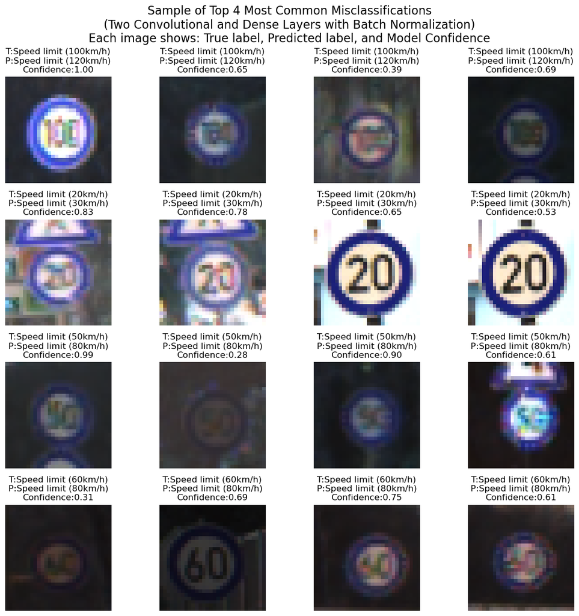

Total Misclassifications: 90

Top 5 Most Common Misclassifications:

* Speed limit (100km/h) (label 7) predicted as Speed limit (120km/h) (label 8) — 18 times

* Speed limit (20km/h) (label 0) predicted as Speed limit (30km/h) (label 1) — 15 times

* Speed limit (50km/h) (label 2) predicted as Speed limit (80km/h) (label 5) — 5 times

* Speed limit (60km/h) (label 3) predicted as Speed limit (80km/h) (label 5) — 5 times

* Speed limit (120km/h) (label 8) predicted as Speed limit (100km/h) (label 7) — 4 times

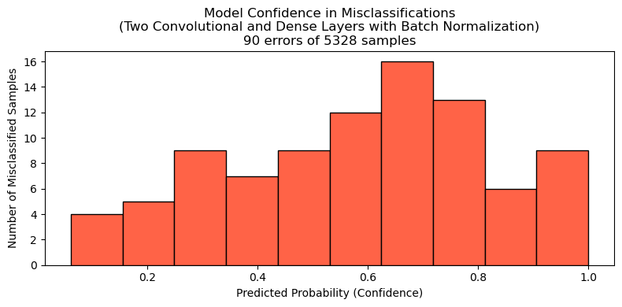

### Results for Two Convolutional + Dense Layers, and Batch Normalization

Adding a second Dense layer to the two-convolutional-layer + batch normalization architecture reduces overall performance compared to the near-perfect two-convolutional + batch normalization model. Accuracy drops to 98.3%, with weighted precision, recall, and f1-score also at ~0.983—strong, but notably below the 99.4% peak achieved without the extra dense layer.

At the class level, performance remains excellent for most categories, with many classes achieving perfect or near-perfect precision and recall. Longstanding problem areas such as class 5 (speed limit signs) hold steady at high performance (precision 0.95, recall 0.98), and minority classes like 6, 21, 29, 33, and 39 remain perfectly classified. However, cracks appear in consistency. Class 0 lags badly (precision 0.94, recall 0.53), while several mid-frequency classes—such as 7 (recall 0.88), 8 (precision 0.90), and 30/41 (f1-scores ~0.96)—underperform relative to earlier convolution-only architectures.

In short, while batch normalization continues to stabilize training, the addition of a second dense layer adds little benefit and slightly degrades performance. The evidence suggests that the optimal architecture for this dataset is the two-convolutional-layer backbone with batch normalization, without additional dense complexity.

# Comparative Model Analysis

Back to Top

In short, the best-performing architecture balances depth and stability without overcomplicating the dense layers. The results highlight the importance of controlled complexity: richer convolutional feature extraction and normalization bring consistent gains, while additional dense layers hurt more than they help.

### Model Comparison Table

| Model | Accuracy | Precision | Recall | F1-score | Errors | Notes |
| --- | --- | --- | --- | --- | --- | --- |
| **Baseline Model** | 96.6% | 0.967 | 0.966 | 0.966 | 183 | A simple, MNIST-style CNN provides a solid foundation but struggles with visually similar or rare signs. |
| **+ Class Weights** | 95.8% | 0.960 | 0.958 | 0.958 | 222 | Helps minority classes at the expense of majority class precision, showing the tradeoff in imbalanced datasets. |
| **+ Conv Layer** | 98.3% | 0.983 | 0.983 | 0.983 | 92 | Adding a second convolutional layer significantly improves feature extraction, reducing confusion among similar signs. |
| **+ Batch Norm** | 98.3% | 0.983 | 0.983 | 0.982 | 93 | Stabilizes training and improves calibration, producing smoother convergence and more consistent results. |
| **+ Conv + BN** | **99.4%** | **0.994** | **0.994** | **0.994** | **31** | The strongest model overall: high accuracy, low error count, and balanced performance across classes. |
| **+ Conv + Dense** | 93.8% | 0.937 | 0.938 | 0.933 | 329 | Demonstrates the risk of unnecessary complexity: overfitting and instability, with entire classes collapsing. |
| **+ Conv + Dense + BN** | 98.3% | 0.983 | 0.983 | 0.983 | 90 | While more complex, it delivers no advantage over the simpler Conv+BN model, underscoring the value of parsimony. |

- **Accuracy**: Proportion of all predictions that are correct.
- **Precision**: Proportion of positive predictions that are correct (True Positives / [True Positives + False Positives]).
- **Recall**: Proportion of actual positives correctly identified (True Positives / [True Positives + False Negatives]).
- **F1-score**: Harmonic mean balancing precision and recall equally.
- **Errors**: Number of misclassifications of 5328 total samples in validation set.

The progression of models illustrates how incremental architectural changes impact performance:

#### Baseline Model

The baseline provides a strong foundation, achieving 96.6% accuracy, with weighted precision, recall, and f1-scores all around 0.966–0.967. Performance is generally high across most classes, with many exceeding 0.95 on all metrics, even in minority categories. Weaknesses appear in challenging classes: class 5 (speed limits) shows precision of 0.82, while classes 20 and 30 underperform in the mid-80s for precision and recall. Some minority classes also lag (e.g., class 19 recall 0.84, class 29 recall 0.85). Training and validation curves suggest the gap is due to dropout rather than genuine overfitting, and the confidence histogram indicates reasonably balanced predictions. Overall, this baseline is robust but highlights systematic challenges with class imbalance and visually similar signs.

#### +Class Weights

Applying class weighting targets underrepresented categories, leading to notable improvements in some minority classes: class 29 recall rises from 0.85 to 0.88, and class 19 from 0.84 to 0.97. However, this comes at a small cost to majority classes: class 5 precision drops from 0.82 to 0.78, and class 2 recall decreases from 0.90 to 0.78. Overall accuracy slightly decreases to 95.8%, with weighted metrics just below 0.96. This model demonstrates the tradeoff inherent in rebalancing: minority performance improves while some majority classes lose ground, highlighting the importance of careful weighting.

#### +Convolutional Layer

Adding a second convolutional layer significantly improves performance. Accuracy rises to 98.3%, with precision, recall, and f1 all around 0.983. Misclassifications among visually similar signs, such as class 5, are reduced (precision rises from 0.82 → 0.90). Minority classes stabilize, with fewer extreme outliers in class-level scores. Training remains smooth, with no signs of overfitting, and confidence calibration is consistent. The added depth allows the network to capture richer hierarchical features, directly reducing systematic errors.

#### +Batch Normalization

Introducing Batch Normalization (BN) after the convolutional layers stabilizes learning. Accuracy remains at 98.3%, with weighted metrics around 0.983. Training curves converge more cleanly, and generalization improves across epochs. Minority classes, particularly 19 and 29, show enhanced performance, reaching near parity with majority classes. Calibration improves, with fewer overconfident misclassifications. BN reduces variance and smooths the learning process, making training more consistent and reliable.

#### +Convolutional Layer + Batch Normalization

Combining an extra convolutional layer with batch normalization delivers peak performance. Accuracy reaches 99.4%, with weighted precision, recall, and f1 all at 0.994. Nearly all classes achieve precision and recall above 0.95, and previously challenging classes like 5 reach 0.97 precision. Training is stable, validation gaps are minimal, and predictions show excellent calibration. This architecture strikes the optimal balance between depth, regularization, and efficiency, achieving both high accuracy and reliable performance across classes.

#### +Dense Layer

Adding a second Dense layer after the convolutional blocks destabilizes performance. Accuracy drops sharply to 93.8%, with weighted metrics around 0.933–0.938. Several classes collapse entirely (e.g., 24 with 0.0 for all scores, 27 with recall 0.21), and others such as 20, 28, and 30 fall below 0.80 f1. Even mid-sized classes (e.g., 7, f1 = 0.79) degrade, highlighting the sensitivity of minority categories. The added dense capacity introduces overfitting and overwhelms feature extraction from the convolutional layers.

#### Overall Trajectory

Across the progression, accuracy improves from 96.6% (Baseline) to 99.4% (+Conv+BN). Class weighting boosts minority classes at the cost of majority performance, convolutional layers enhance feature extraction, and batch normalization stabilizes training and calibration. Dense layers beyond convolutional + BN show diminishing or negative returns. The optimal architecture—two convolutional layers with batch normalization—provides the best balance of accuracy, stability, and class-level consistency.

## Two Convolutional Layers with Batch Normalization

Taken together, the model progression illustrates how careful architectural choices can systematically close the gap between a strong baseline and near-perfect classification. Each enhancement—class weighting, additional convolutional layers, and batch normalization—addresses a specific limitation, from class imbalance to feature extraction and training stability. The story of the project shows that thoughtful design, rather than brute-force complexity, yields the most accurate, reliable, and generalizable neural network for traffic sign recognition.

# Test Set Evaluation

Back to Top

With training complete, the ultimate test of any model is performance on unseen data. In this section, the best-performing architecture—two convolutional layers with batch normalization—is evaluated against the GTSRB test set. The results provide a final check on generalization, class balance, and robustness under real-world conditions.

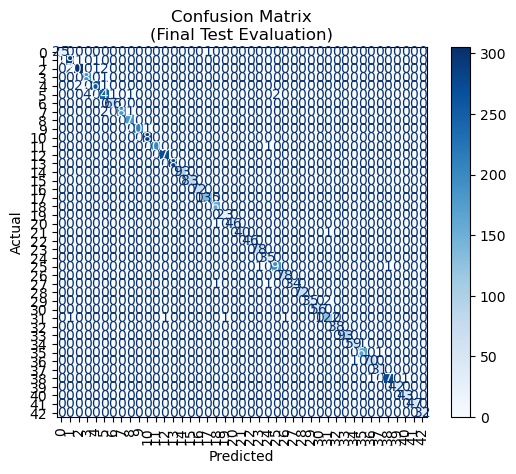

Classification Report

|  | precision | recall | f1-score | support |
| --- | --- | --- | --- | --- |
| accuracy | 0.991929 | 0.991929 | 0.991929 | 0.991929 |
| macro avg | 0.990396 | 0.991160 | 0.990690 | 5328.000000 |
| weighted avg | 0.991979 | 0.991929 | 0.991921 | 5328.000000 |
| 0 | 0.961538 | 0.961538 | 0.961538 | 26.000000 |
| 1 | 0.989761 | 0.989761 | 0.989761 | 293.000000 |
| 2 | 0.990260 | 0.983871 | 0.987055 | 310.000000 |
| 3 | 0.979275 | 0.994737 | 0.986945 | 190.000000 |
| 4 | 0.992453 | 0.988722 | 0.990584 | 266.000000 |
| 5 | 0.976285 | 0.968627 | 0.972441 | 255.000000 |
| 6 | 0.985075 | 1.000000 | 0.992481 | 66.000000 |
| 7 | 1.000000 | 0.983607 | 0.991736 | 183.000000 |
| 8 | 0.988827 | 1.000000 | 0.994382 | 177.000000 |
| 9 | 1.000000 | 0.995169 | 0.997579 | 207.000000 |
| 10 | 0.996503 | 1.000000 | 0.998249 | 285.000000 |
| 11 | 1.000000 | 0.995074 | 0.997531 | 203.000000 |
| 12 | 0.996310 | 1.000000 | 0.998152 | 270.000000 |
| 13 | 1.000000 | 1.000000 | 1.000000 | 281.000000 |
| 14 | 1.000000 | 1.000000 | 1.000000 | 93.000000 |
| 15 | 1.000000 | 1.000000 | 1.000000 | 83.000000 |
| 16 | 1.000000 | 1.000000 | 1.000000 | 72.000000 |
| 17 | 0.992647 | 1.000000 | 0.996310 | 135.000000 |
| 18 | 0.987730 | 1.000000 | 0.993827 | 161.000000 |
| 19 | 0.958333 | 1.000000 | 0.978723 | 23.000000 |
| 20 | 1.000000 | 0.978723 | 0.989247 | 47.000000 |
| 21 | 1.000000 | 0.975610 | 0.987654 | 41.000000 |
| 22 | 1.000000 | 1.000000 | 1.000000 | 46.000000 |
| 23 | 0.987342 | 1.000000 | 0.993631 | 78.000000 |
| 24 | 0.945946 | 1.000000 | 0.972222 | 35.000000 |
| 25 | 0.989691 | 0.989691 | 0.989691 | 194.000000 |
| 26 | 0.987342 | 1.000000 | 0.993631 | 78.000000 |
| 27 | 1.000000 | 0.944444 | 0.971429 | 36.000000 |
| 28 | 1.000000 | 1.000000 | 1.000000 | 72.000000 |
| 29 | 1.000000 | 0.945946 | 0.972222 | 37.000000 |
| 30 | 1.000000 | 1.000000 | 1.000000 | 56.000000 |
| 31 | 0.976000 | 0.968254 | 0.972112 | 126.000000 |
| 32 | 1.000000 | 1.000000 | 1.000000 | 38.000000 |
| 33 | 1.000000 | 1.000000 | 1.000000 | 93.000000 |
| 34 | 0.983333 | 0.983333 | 0.983333 | 60.000000 |
| 35 | 0.994083 | 0.994083 | 0.994083 | 169.000000 |
| 36 | 0.985915 | 0.985915 | 0.985915 | 71.000000 |
| 37 | 0.968750 | 1.000000 | 0.984127 | 31.000000 |
| 38 | 0.996377 | 0.992780 | 0.994575 | 277.000000 |
| 39 | 1.000000 | 1.000000 | 1.000000 | 42.000000 |
| 40 | 0.977273 | 1.000000 | 0.988506 | 43.000000 |
| 41 | 1.000000 | 1.000000 | 1.000000 | 47.000000 |
| 42 | 1.000000 | 1.000000 | 1.000000 | 32.000000 |

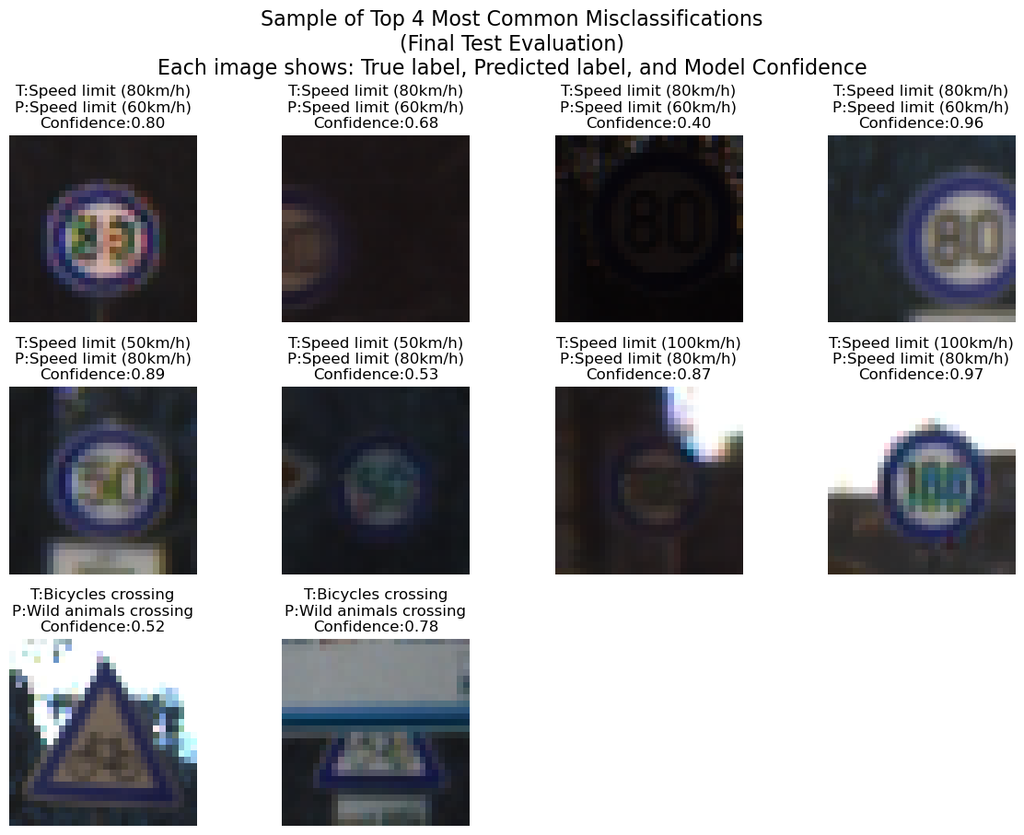

Total Misclassifications: 43

Top 5 Most Common Misclassifications:

* Speed limit (80km/h) (label 5) predicted as Speed limit (60km/h) (label 3) — 4 times

* Speed limit (50km/h) (label 2) predicted as Speed limit (80km/h) (label 5) — 2 times

* Speed limit (100km/h) (label 7) predicted as Speed limit (80km/h) (label 5) — 2 times

* Bicycles crossing (label 29) predicted as Wild animals crossing (label 31) — 2 times

* Speed limit (70km/h) (label 4) predicted as Speed limit (50km/h) (label 2) — 2 times

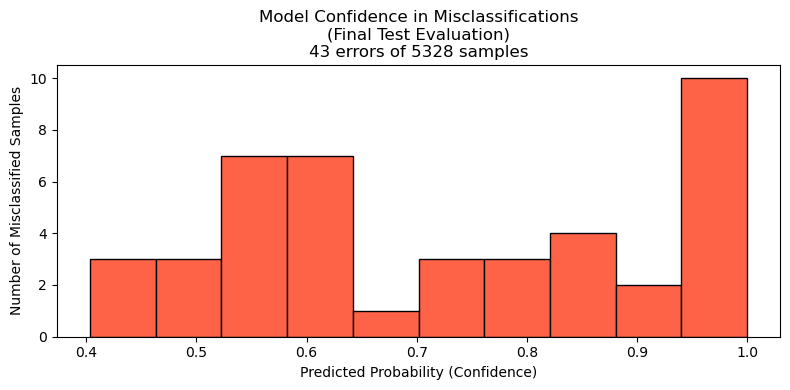

# Interpretation of Test Results

Back to Top

The final model achieved **99.2% accuracy on the test set**, with weighted precision, recall, and f1-scores all at **0.99**. Performance was consistent across nearly all 43 traffic sign classes, including those with limited samples. A handful of smaller categories (e.g., classes 24, 27, 29) showed slightly lower F1-scores around 0.97, but the majority reached or exceeded 0.99, with many attaining perfect scores. These results confirm that the chosen architecture balances generalization and robustness, delivering near state-of-the-art performance without unnecessary complexity.

Taken together, the model progression demonstrates how targeted architectural choices—rather than simply adding more layers—can drive performance from a solid baseline to near-perfect classification. Each enhancement systematically addressed a specific limitation, from class imbalance to learning stability and feature representation.

## In Conclusion

From the baseline model to the final two-layer convolutional network with batch normalization, the results tell a clear story: careful design choices, combined with strategic use of class weighting and normalization, steadily closed gaps in minority and visually similar classes. The final architecture proved both **highly accurate** and **consistently reliable**, underscoring that well-placed refinements—not sheer complexity—are the key to building effective deep learning models.

Taken together, these findings demonstrate how careful model selection and feature engineering can balance interpretability with predictive power. The approaches outlined here not only address the immediate problem but also illustrate broadly applicable strategies for working with complex, imbalanced data. Looking ahead, scaling these methods to higher-resolution datasets and applying transfer learning across related domains will expand their real-world impact, enabling more accurate and timely insights in operational decision-making.